# Trabajo práctico AID C1 2022

Damián Fontenla

2022-05-10

## Consignas

#### *1.- Para la base de datos seleccionada genere una muestra aleatoria estratificada ybalanceada por variedad de vino de tamaño n = 2000 utilizando como semilla los últimos tres dígitos del DNI/PASAPORTE.*

```r
datos_tp <-read_excel("DatosTP1.xlsx")
glimpse(datos_tp)
```

```
## Rows: 6,497
## Columns: 13
## $ `acidez fija`               <dbl> 7.0, 6.3, 8.1, 7.2, 7.2, 8.1, 6.2, 7.0, 6.…
## $ `acidez volátil`            <dbl> 0.27, 0.30, 0.28, 0.23, 0.23, 0.28, 0.32, …
## $ `ácido cítrico`             <dbl> 0.36, 0.34, 0.40, 0.32, 0.32, 0.40, 0.16, …
## $ `azúcar residual`           <dbl> 20.70, 1.60, 6.90, 8.50, 8.50, 6.90, 7.00,…
## $ cloruros                    <dbl> 0.045, 0.049, 0.050, 0.058, 0.058, 0.050, …
## $ `anhídrido sulfuroso libre` <dbl> 45, 14, 30, 47, 47, 30, 30, 45, 14, 28, 11…
## $ `anhídrido sulfuroso total` <dbl> 170, 132, 97, 186, 186, 97, 136, 170, 132,…
## $ densidad                    <dbl> 1.0010, 0.9940, 0.9951, 0.9956, 0.9956, 0.…
## $ pH                          <dbl> 3.00, 3.30, 3.26, 3.19, 3.19, 3.26, 3.18, …
## $ sulfatos                    <dbl> 0.45, 0.49, 0.44, 0.40, 0.40, 0.44, 0.47, …
## $ alcohol                     <dbl> 8.8, 9.5, 10.1, 9.9, 9.9, 10.1, 9.6, 8.8, …
## $ calidad                     <dbl> 6, 6, 6, 6, 6, 6, 6, 6, 6, 6, 5, 5, 5, 7, …
## $ variedad                    <dbl> 1, 1, 1, 1, 1, 1, 1, 1, 1, 1, 1, 1, 1, 1, …
```

```r
set.seed(661) #fijo la semilla

sample_var_1 = datos_tp %>% filter(datos_tp$variedad == 1)
sample_var_2 = datos_tp %>% filter(datos_tp$variedad == 2)
index_sample_data_1 <- sample(1:nrow(sample_var_1), size=1000, replace=FALSE)
index_sample_data_2 <- sample(1:nrow(sample_var_2), size=1000, replace=FALSE)
sample_data_var_1 = sample_var_1[index_sample_data_1,]
sample_data_var_2 = sample_var_2[index_sample_data_2,]
sample_data <- rbindlist(list(sample_data_var_1, sample_data_var_2))    # Rbind data.tables

glimpse(sample_data)
```

```
## Rows: 2,000
## Columns: 13
## $ `acidez fija`               <dbl> 5.9, 5.8, 9.1, 6.9, 7.2, 7.2, 7.4, 5.2, 7.…
## $ `acidez volátil`            <dbl> 0.320, 0.300, 0.280, 0.250, 0.230, 0.230, …
## $ `ácido cítrico`             <dbl> 0.26, 0.27, 0.49, 0.35, 0.32, 0.19, 0.27, …
## $ `azúcar residual`           <dbl> 1.5, 1.7, 2.0, 9.2, 8.5, 13.7, 1.2, 1.1, 1…
## $ cloruros                    <dbl> 0.057, 0.014, 0.059, 0.034, 0.058, 0.052, …
## $ `anhídrido sulfuroso libre` <dbl> 17.0, 45.0, 10.0, 42.0, 47.0, 47.0, 27.0, …
## $ `anhídrido sulfuroso total` <dbl> 141, 104, 112, 150, 186, 197, 99, 69, 112,…
## $ densidad                    <dbl> 0.99170, 0.98914, 0.99580, 0.99470, 0.9956…
## $ pH                          <dbl> 3.24, 3.40, 3.15, 3.21, 3.19, 3.12, 3.19, …
## $ sulfatos                    <dbl> 0.36, 0.56, 0.46, 0.36, 0.40, 0.53, 0.33, …
## $ alcohol                     <dbl> 10.700000, 12.600000, 10.100000, 11.500000…
## $ calidad                     <dbl> 5, 7, 5, 6, 6, 5, 6, 6, 5, 5, 7, 6, 6, 6, …
## $ variedad                    <dbl> 1, 1, 1, 1, 1, 1, 1, 1, 1, 1, 1, 1, 1, 1, …
```

```r
write_xlsx(sample_data,"df_wines.xlsx")

print(paste("Balanced dataset - Variedad 1: ", nrow((sample_data %>% filter(variedad == 1)))))
```

```
## [1] "Balanced dataset - Variedad 1:  1000"
```

```r
print(paste("Balanced dataset - Variedad 2: ", nrow((sample_data %>% filter(variedad == 2)))))
```

```
## [1] "Balanced dataset - Variedad 2:  1000"
```

#### *2.- Realice un análisis estadístico de cada una de las variables numéricas para cada variedad de vino. Presente la información en forma tabular y conteniendo las siguientes medidas descriptivas: Cantidad de datos, mínimo, máximo, media, mediana, moda, varianza, desviación estándar, coeficiente de variación, cuartil 1, cuartil 3, rango intercuartílico, MAD, asimetría, curtosis.*

##### Variedad 1

```r
vec_names_1 <- names(sample_data_var_1)

for (i in vec_names_1) {
  print(paste("Columna: ",i))
  df_col = data.frame(sample_data_var_1[i])
  print(summary(sample_data_var_1[i]))
  print(paste("Kurtosis", kurtosis(df_col[,])))
  print(paste("Var: ",var(df_col[,])))
  print(paste("Skewness: ",skewness(df_col[,])))
  print(paste("Std: ",sd(df_col[,])))
  cv <- sd(df_col[,]) / mean(df_col[,]) * 100
  print(paste("CV: ", cv))
  print(paste("MAD: ", mad(df_col[,])))
  print(paste("Moda: ",mlv(df_col[,], method = "mfv")))
  print("-------------------------- ")
}
```

```
## [1] "Columna:  acidez fija"
##   acidez fija
##  Min.   :4.400
##  1st Qu.:6.300
##  Median :6.800
##  Mean   :6.854
##  3rd Qu.:7.400
##  Max.   :9.800
## [1] "Kurtosis 3.59681012848921"
## [1] "Var:  0.652494391891892"
## [1] "Skewness:  0.443042035868652"
## [1] "Std:  0.807771249730944"
## [1] "CV:  11.7854850083666"
## [1] "MAD:  0.7413"
## [1] "Moda:  6.6"
## [1] "-------------------------- "
## [1] "Columna:  acidez volátil"
##  acidez volátil
##  Min.   :0.080
##  1st Qu.:0.210
##  Median :0.260
##  Mean   :0.282
##  3rd Qu.:0.330
##  Max.   :1.100
## [1] "Kurtosis 8.2833178707054"
## [1] "Var:  0.0108270608358358"
## [1] "Skewness:  1.56423228293776"
## [1] "Std:  0.104053163507103"
## [1] "CV:  36.8937059255421"
## [1] "MAD:  0.088956"
## [1] "Moda:  0.22"
## [1] "-------------------------- "
## [1] "Columna:  ácido cítrico"
##  ácido cítrico
##  Min.   :0.0200
##  1st Qu.:0.2675
##  Median :0.3200
##  Mean   :0.3404
##  3rd Qu.:0.3900
##  Max.   :1.2300
## [1] "Kurtosis 7.6885263183302"
## [1] "Var:  0.0154380011011011"
```

```
## [1] "Skewness:  1.4179686847626"
## [1] "Std:  0.12424975292169"
## [1] "CV:  36.5043196878956"
## [1] "MAD:  0.088956"
## [1] "Moda:  0.28"
## [1] "-------------------------- "
## [1] "Columna:  azúcar residual"
##  azúcar residual
##  Min.   : 0.600
##  1st Qu.: 1.700
##  Median : 5.200
##  Mean   : 6.491
##  3rd Qu.:10.200
##  Max.   :31.600
## [1] "Kurtosis 2.93074363342386"
## [1] "Var:  26.0556228128128"
## [1] "Skewness:  0.811603706598849"
## [1] "Std:  5.10447086511548"
## [1] "CV:  78.6404175863976"
## [1] "MAD:  5.33736"
## [1] "Moda:  1.4"
## [1] "-------------------------- "
## [1] "Columna:  cloruros"
##     cloruros
##  Min.   :0.01200
##  1st Qu.:0.03575
##  Median :0.04200
##  Mean   :0.04621
##  3rd Qu.:0.05000
##  Max.   :0.29000
## [1] "Kurtosis 35.0780448723163"
## [1] "Var:  0.000563044363363363"
```

```
## [1] "Skewness:  4.83372575725317"
## [1] "Std:  0.0237285558634183"
## [1] "CV:  51.3505071813246"
## [1] "MAD:  0.0103782"
## [1] "Moda:  0.036" "Moda:  0.044"
## [1] "-------------------------- "
## [1] "Columna:  anhídrido sulfuroso libre"
##  anhídrido sulfuroso libre
##  Min.   :  2.00
##  1st Qu.: 23.00
##  Median : 34.00
##  Mean   : 35.95
##  3rd Qu.: 47.00
##  Max.   :289.00
## [1] "Kurtosis 33.4361362330342"
## [1] "Var:  373.565861861862"
```

```
## [1] "Skewness:  3.00901188574887"
## [1] "Std:  19.3278519722669"
## [1] "CV:  53.7661399028233"
## [1] "MAD:  17.0499"
## [1] "Moda:  29"
## [1] "-------------------------- "
## [1] "Columna:  anhídrido sulfuroso total"
##  anhídrido sulfuroso total
##  Min.   :  9.0
##  1st Qu.:109.0
##  Median :137.0
##  Mean   :140.1
##  3rd Qu.:169.0
##  Max.   :440.0
## [1] "Kurtosis 4.93985986464682"
## [1] "Var:  1907.8312022022"
```

```
## [1] "Skewness:  0.581296033455793"
## [1] "Std:  43.6787271128887"
## [1] "CV:  31.1708144132742"
## [1] "MAD:  44.478"
## [1] "Moda:  107" "Moda:  113" "Moda:  140"
## [1] "-------------------------- "
## [1] "Columna:  densidad"
##     densidad
##  Min.   :0.9872
##  1st Qu.:0.9917
##  Median :0.9939
##  Mean   :0.9941
##  3rd Qu.:0.9963
##  Max.   :1.0103
## [1] "Kurtosis 2.93829794262268"
## [1] "Var:  8.85478725603103e-06"
## [1] "Skewness:  0.378465865008188"
## [1] "Std:  0.00297569945660361"
## [1] "CV:  0.299338200770023"
## [1] "MAD:  0.00335808899999994"
## [1] "Moda:  0.9928"
## [1] "-------------------------- "
## [1] "Columna:  pH"
##        pH
##  Min.   :2.790
##  1st Qu.:3.080
##  Median :3.170
##  Mean   :3.186
##  3rd Qu.:3.280
##  Max.   :3.800
## [1] "Kurtosis 3.31089008517041"
## [1] "Var:  0.0224689633633634"
```

```
## [1] "Skewness:  0.383410597730105"
## [1] "Std:  0.149896508843146"
## [1] "CV:  4.70508590648451"
## [1] "MAD:  0.14826"
## [1] "Moda:  3.14"
## [1] "-------------------------- "
## [1] "Columna:  sulfatos"
##     sulfatos
##  Min.   :0.2300
##  1st Qu.:0.4100
##  Median :0.4800
##  Mean   :0.4908
##  3rd Qu.:0.5400
##  Max.   :1.0600
## [1] "Kurtosis 4.58521613479111"
## [1] "Var:  0.0132245316316316"
```

```
## [1] "Skewness:  0.976938508221296"
## [1] "Std:  0.11499796359776"
## [1] "CV:  23.4321502124742"
## [1] "MAD:  0.103782"
## [1] "Moda:  0.5"
## [1] "-------------------------- "
## [1] "Columna:  alcohol"
##     alcohol
##  Min.   : 8.00
##  1st Qu.: 9.40
##  Median :10.30
##  Mean   :10.48
##  3rd Qu.:11.40
##  Max.   :14.00
## [1] "Kurtosis 2.35953130360002"
## [1] "Var:  1.51260503809365"
## [1] "Skewness:  0.510477168259435"
## [1] "Std:  1.22988009094125"
## [1] "CV:  11.7302922934122"
## [1] "MAD:  1.33434"
## [1] "Moda:  9"
## [1] "-------------------------- "
## [1] "Columna:  calidad"
##     calidad
##  Min.   :3.000
##  1st Qu.:5.000
##  Median :6.000
##  Mean   :5.871
##  3rd Qu.:6.000
##  Max.   :9.000
## [1] "Kurtosis 3.41670469042901"
## [1] "Var:  0.833192192192192"
```

```
## [1] "Skewness:  0.0753020031591806"
## [1] "Std:  0.91279361971488"
## [1] "CV:  15.5474982066919"
## [1] "MAD:  1.4826"
## [1] "Moda:  6"
## [1] "-------------------------- "
## [1] "Columna:  variedad"
##     variedad
##  Min.   :1
##  1st Qu.:1
##  Median :1
##  Mean   :1
##  3rd Qu.:1
##  Max.   :1
## [1] "Kurtosis NaN"
## [1] "Var:  0"
```

```
## [1] "Skewness:  NaN"
## [1] "Std:  0"
## [1] "CV:  0"
## [1] "MAD:  0"
## [1] "Moda:  1"
## [1] "-------------------------- "
```

##### Variedad 2

```r
vec_names_2 <- names(sample_data_var_2)

for (i in vec_names_2) {
  print(paste("Columna: ",i))
  df_col = data.frame(sample_data_var_2[i])
  print(summary(sample_data_var_2[i]))
  print(paste("Kurtosis", kurtosis(df_col[,])))
  print(paste("Var: ",var(df_col[,])))
  print(paste("Skewness: ",skewness(df_col[,])))
  print(paste("Std: ",sd(df_col[,])))
  cv <- sd(df_col[,]) / mean(df_col[,]) * 100
  print(paste("CV: ", cv))
  print(paste("MAD: ", mad(df_col[,])))
  print(paste("Moda: ",mlv(df_col[,], method = "mfv")))
  print("-------------------------- ")
}
```

```
## [1] "Columna:  acidez fija"
##   acidez fija
##  Min.   : 4.700
##  1st Qu.: 7.100
##  Median : 7.900
##  Mean   : 8.354
##  3rd Qu.: 9.300
##  Max.   :15.900
## [1] "Kurtosis 3.92348836456097"
## [1] "Var:  3.09580211211211"
## [1] "Skewness:  0.917884226134783"
## [1] "Std:  1.75948916226049"
## [1] "CV:  21.0623934575157"
## [1] "MAD:  1.4826"
## [1] "Moda:  7.2" "Moda:  7.8"
## [1] "-------------------------- "
## [1] "Columna:  acidez volátil"
##  acidez volátil
##  Min.   :0.1200
##  1st Qu.:0.3900
##  Median :0.5100
##  Mean   :0.5213
##  3rd Qu.:0.6300
##  Max.   :1.5800
## [1] "Kurtosis 4.42998812985221"
## [1] "Var:  0.0323916227227227"
## [1] "Skewness:  0.74047596254637"
## [1] "Std:  0.179976728280972"
## [1] "CV:  34.5226110680321"
## [1] "MAD:  0.177912"
## [1] "Moda:  0.6"
## [1] "-------------------------- "
## [1] "Columna:  ácido cítrico"
##  ácido cítrico
##  Min.   :0.0000
##  1st Qu.:0.0900
##  Median :0.2700
##  Mean   :0.2762
##  3rd Qu.:0.4400
##  Max.   :1.0000
## [1] "Kurtosis 2.18688878175729"
## [1] "Var:  0.0394672031031031"
## [1] "Skewness:  0.265728607223024"
## [1] "Std:  0.198663542460873"
## [1] "CV:  71.9248189641479"
## [1] "MAD:  0.252042"
## [1] "Moda:  0"
## [1] "-------------------------- "
## [1] "Columna:  azúcar residual"
##  azúcar residual
##  Min.   : 0.900
##  1st Qu.: 1.900
##  Median : 2.200
##  Mean   : 2.549
##  3rd Qu.: 2.600
##  Max.   :15.500
## [1] "Kurtosis 33.8674984992446"
## [1] "Var:  2.13561220970971"
```

```
## [1] "Skewness:  4.74144457330232"
## [1] "Std:  1.46137339845424"
## [1] "CV:  57.3301190033246"
## [1] "MAD:  0.59304"
## [1] "Moda:  2"
## [1] "-------------------------- "
## [1] "Columna:  cloruros"
##     cloruros
##  Min.   :0.01200
##  1st Qu.:0.07000
##  Median :0.07900
##  Mean   :0.08769
##  3rd Qu.:0.09000
##  Max.   :0.61100
## [1] "Kurtosis 46.2940860081612"
## [1] "Var:  0.00240436702302302"
```

```
## [1] "Skewness:  5.80733419517592"
## [1] "Std:  0.0490343453410262"
## [1] "CV:  55.9191056256572"
## [1] "MAD:  0.014826"
## [1] "Moda:  0.08"
## [1] "-------------------------- "
## [1] "Columna:  anhídrido sulfuroso libre"
##  anhídrido sulfuroso libre
##  Min.   : 1.00
##  1st Qu.: 7.00
##  Median :14.00
##  Mean   :15.91
##  3rd Qu.:21.00
##  Max.   :72.00
## [1] "Kurtosis 5.03686943742513"
## [1] "Var:  105.466897897898"
## [1] "Skewness:  1.22612113764368"
## [1] "Std:  10.2697077805504"
## [1] "CV:  64.5365913438724"
## [1] "MAD:  10.3782"
## [1] "Moda:  6"
## [1] "-------------------------- "
## [1] "Columna:  anhídrido sulfuroso total"
##  anhídrido sulfuroso total
##  Min.   :  6.00
##  1st Qu.: 22.00
##  Median : 37.00
##  Mean   : 46.34
##  3rd Qu.: 61.00
##  Max.   :289.00
## [1] "Kurtosis 8.24154398088282"
## [1] "Var:  1125.72138538539"
## [1] "Skewness:  1.71444356726379"
## [1] "Std:  33.5517717175321"
## [1] "CV:  72.3972288053083"
## [1] "MAD:  26.6868"
## [1] "Moda:  15"
## [1] "-------------------------- "
## [1] "Columna:  densidad"
##     densidad
```

[output cut: 9 more lines]

```
## [1] "Std:  0.00193560944602146"
## [1] "CV:  0.19418766977132"
## [1] "MAD:  0.00170498999999998"
## [1] "Moda:  0.9972"
## [1] "-------------------------- "
## [1] "Columna:  pH"
##        pH
##  Min.   :2.740
##  1st Qu.:3.210
##  Median :3.310
##  Mean   :3.309
##  3rd Qu.:3.400
##  Max.   :4.010
## [1] "Kurtosis 3.89564646115506"
## [1] "Var:  0.0243893644644645"
```

```
## [1] "Skewness:  0.164605430840141"
## [1] "Std:  0.15617094628792"
## [1] "CV:  4.71896810894686"
## [1] "MAD:  0.14826"
## [1] "Moda:  3.36" "Moda:  3.39"
## [1] "-------------------------- "
## [1] "Columna:  sulfatos"
##     sulfatos
##  Min.   :0.3300
##  1st Qu.:0.5500
##  Median :0.6200
##  Mean   :0.6619
##  3rd Qu.:0.7300
##  Max.   :2.0000
## [1] "Kurtosis 17.187994881778"
## [1] "Var:  0.0314533189189189"
## [1] "Skewness:  2.75613791216292"
## [1] "Std:  0.177350835687117"
## [1] "CV:  26.7950135503592"
## [1] "MAD:  0.118608"
## [1] "Moda:  0.54"
## [1] "-------------------------- "
## [1] "Columna:  alcohol"
##     alcohol
##  Min.   : 8.70
##  1st Qu.: 9.50
##  Median :10.20
##  Mean   :10.45
##  3rd Qu.:11.20
##  Max.   :14.90
## [1] "Kurtosis 3.17639055790618"
## [1] "Var:  1.19244622149928"
```

```
## [1] "Skewness:  0.859960325900503"
## [1] "Std:  1.0919918596305"
## [1] "CV:  10.4480664997329"
## [1] "MAD:  1.03782"
## [1] "Moda:  9.5"
## [1] "-------------------------- "
## [1] "Columna:  calidad"
##     calidad
##  Min.   :3.000
##  1st Qu.:5.000
##  Median :6.000
##  Mean   :5.645
##  3rd Qu.:6.000
##  Max.   :8.000
## [1] "Kurtosis 3.46259684155656"
## [1] "Var:  0.663638638638639"
```

```
## [1] "Skewness:  0.221608086631315"
## [1] "Std:  0.814640189678019"
## [1] "CV:  14.4311813937647"
## [1] "MAD:  1.4826"
## [1] "Moda:  5"
## [1] "-------------------------- "
## [1] "Columna:  variedad"
##     variedad
##  Min.   :2
##  1st Qu.:2
##  Median :2
##  Mean   :2
##  3rd Qu.:2
##  Max.   :2
## [1] "Kurtosis NaN"
## [1] "Var:  0"
```

```
## [1] "Skewness:  NaN"
## [1] "Std:  0"
## [1] "CV:  0"
## [1] "MAD:  0"
## [1] "Moda:  2"
## [1] "-------------------------- "
```

#### *3.- Represente gráficamente cada variable eligiendo el gráfico que considere apropiado. Considere la posibilidad de generar rangos de datos para su análisis y representación gráfica de las variables.*

Utilizo **boxplot** para todas las variable que me interese ver sus outliers, distribución, análisis de la media y varianza

Utilizo **hist** para comprender la distribución de una variable categórica

Utilizo **barplot** para entender el balancedo de otra variable categórica

Utilizo **barplot** separando el dataset segun su variedad si comparando el resto de los atributos

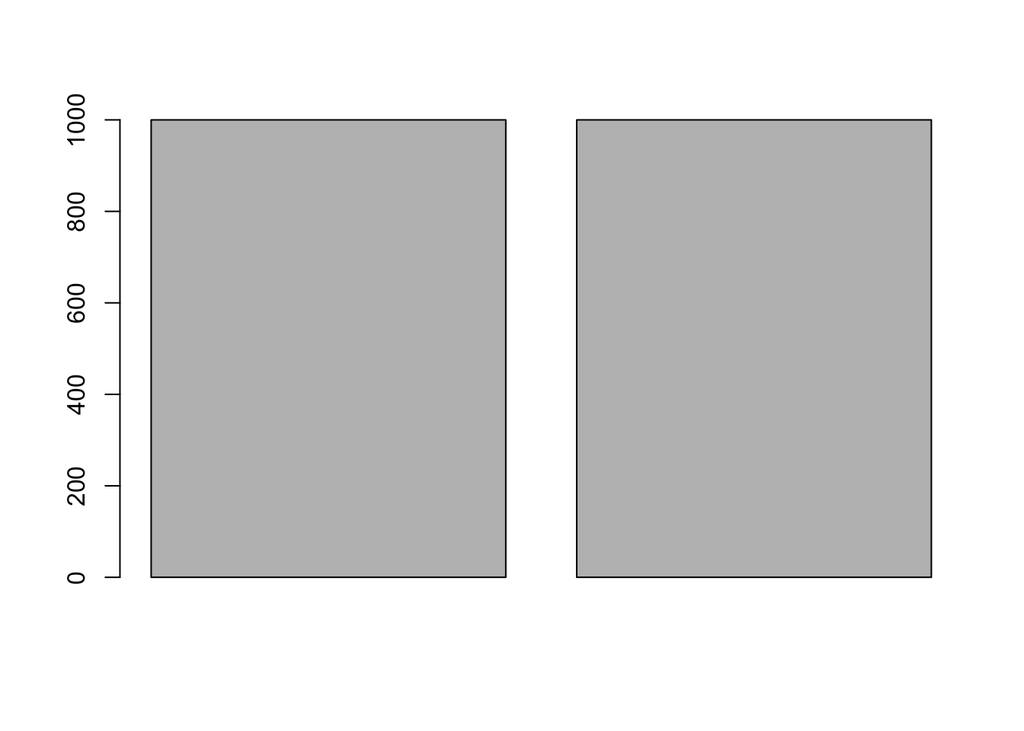

```r
barplot(c(length(sample_data_var_1$variedad), length(sample_data_var_2$variedad)))
```

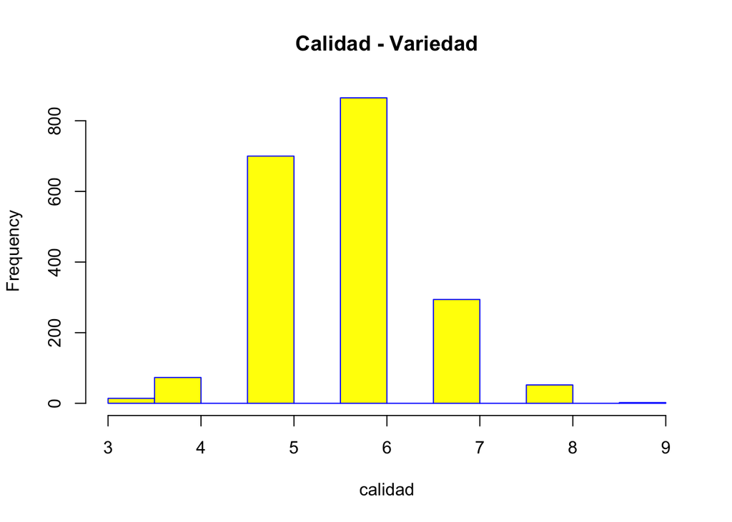

```r
hist(sample_data$calidad,xlab = "calidad",col = "yellow",border = "blue", main = "Calidad - Variedad")
```

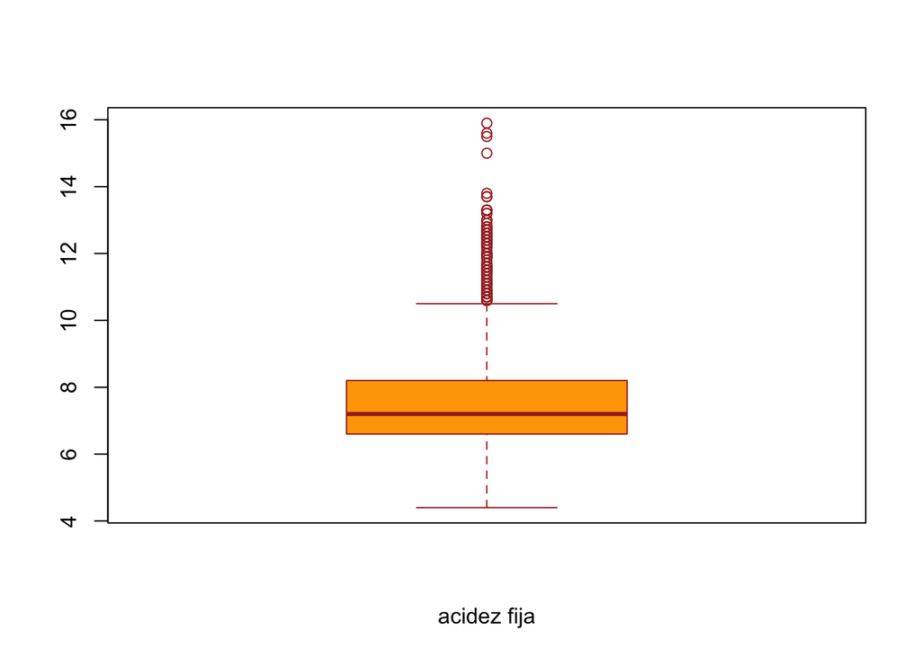

```r
boxplot(sample_data$`acidez fija`,data=sample_data,xlab="acidez fija",col="orange",border="brown")
```

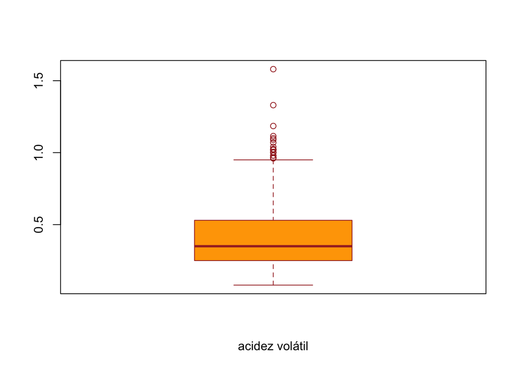

```r
boxplot(sample_data$`acidez volátil`,data=sample_data,xlab="acidez volátil",col="orange",border="brown")
```

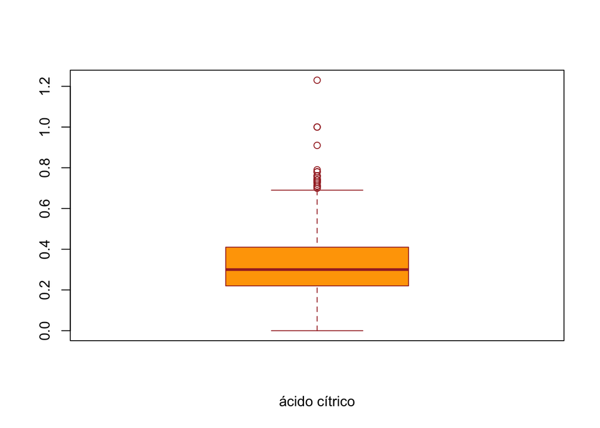

```r
boxplot(sample_data$`ácido cítrico`,data=sample_data,xlab="ácido cítrico",col="orange",border="brown")
```

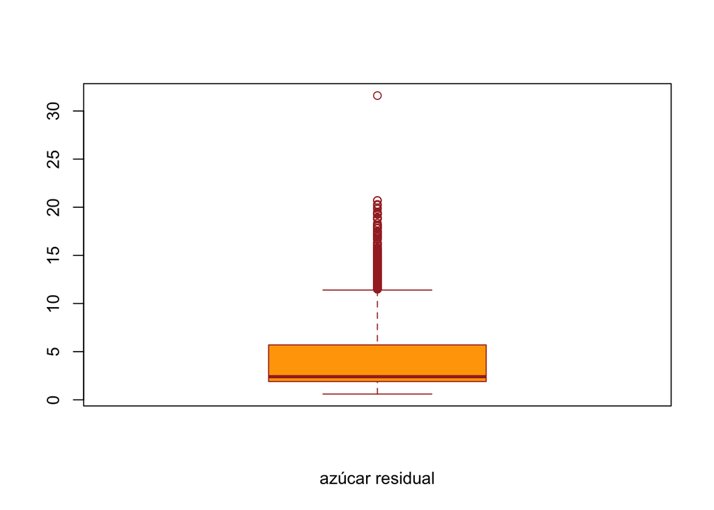

```r
boxplot(sample_data$`azúcar residual`,data=sample_data,xlab="azúcar residual",col="orange",border="brown")
```

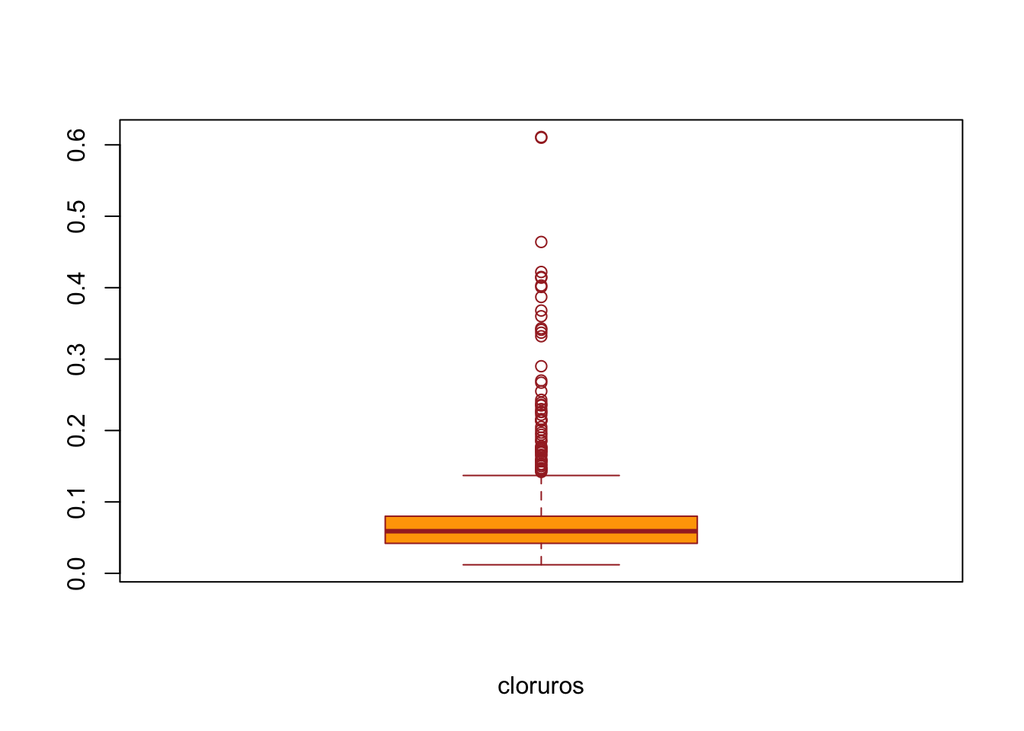

```r
boxplot(sample_data$cloruros,data=sample_data,xlab="cloruros",col="orange",border="brown")
```

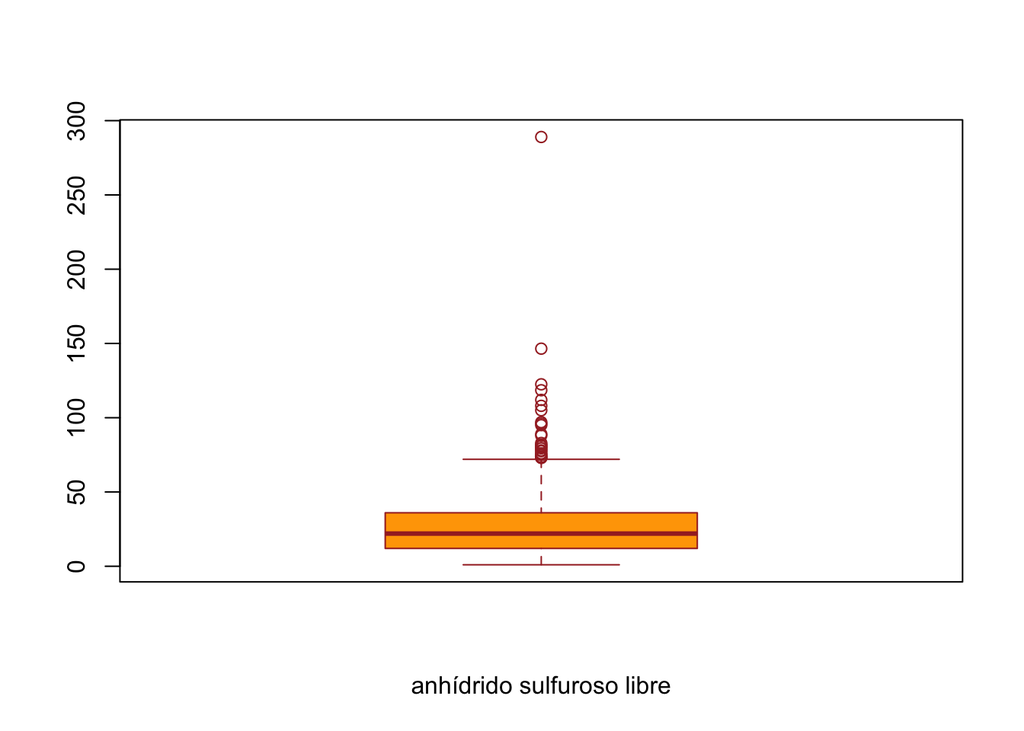

```r
boxplot(sample_data$`anhídrido sulfuroso libre`,data=sample_data,xlab="anhídrido sulfuroso libre",col="orange",border="brown")
```

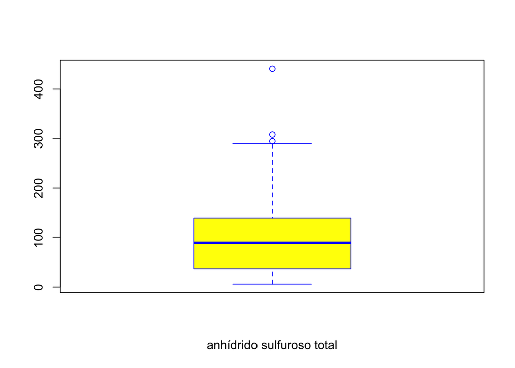

```r
boxplot(sample_data$`anhídrido sulfuroso total`,xlab = "anhídrido sulfuroso total",col = "yellow",border = "blue")
```

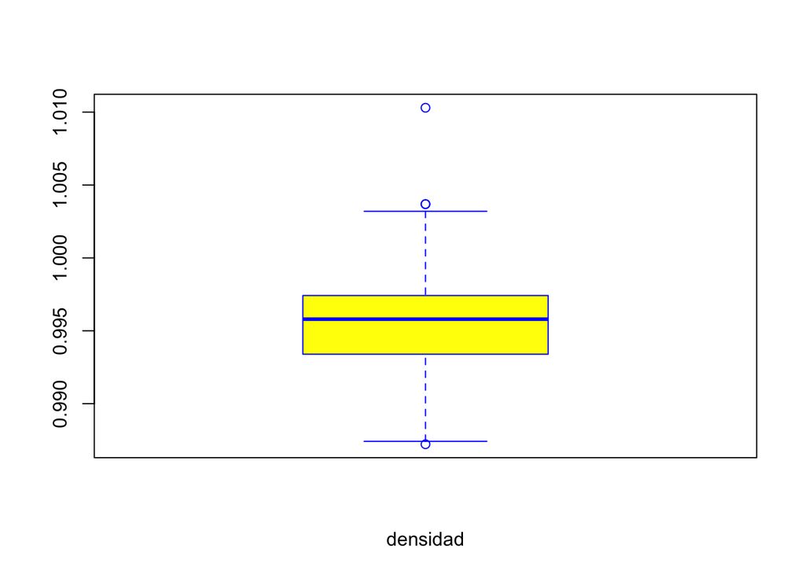

```r
boxplot(sample_data$densidad,xlab = "densidad",col = "yellow",border = "blue")
```

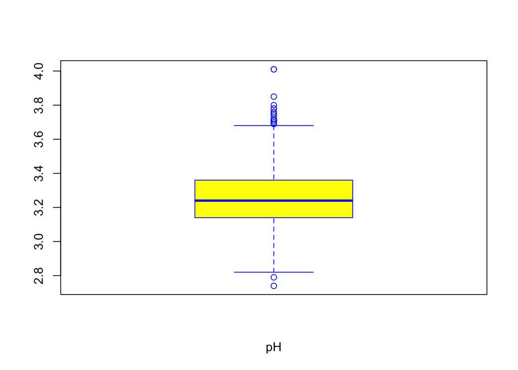

```r
boxplot(sample_data$pH,xlab = "pH",col = "yellow",border = "blue")
```

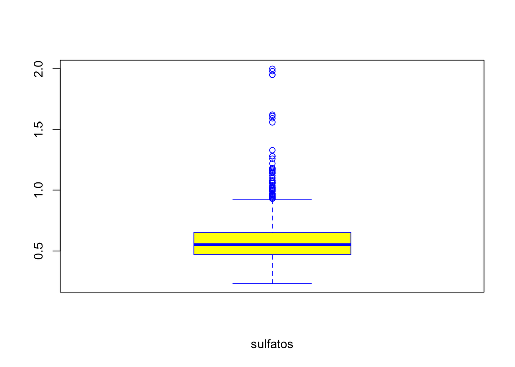

```r
boxplot(sample_data$sulfatos,xlab = "sulfatos",col = "yellow",border = "blue")
```

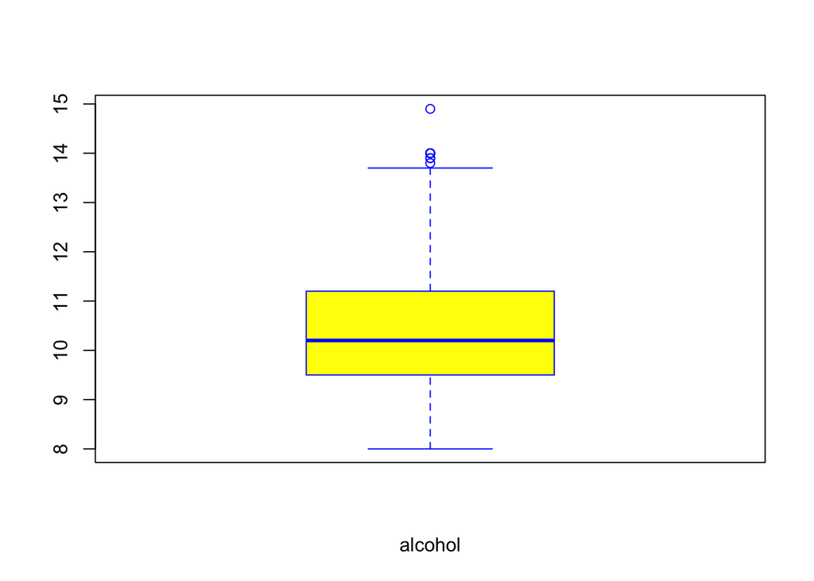

```r
boxplot(sample_data$alcohol,xlab = "alcohol",col = "yellow",border = "blue")
```

Separo el dataset para ver las diferenciaciones por variedad

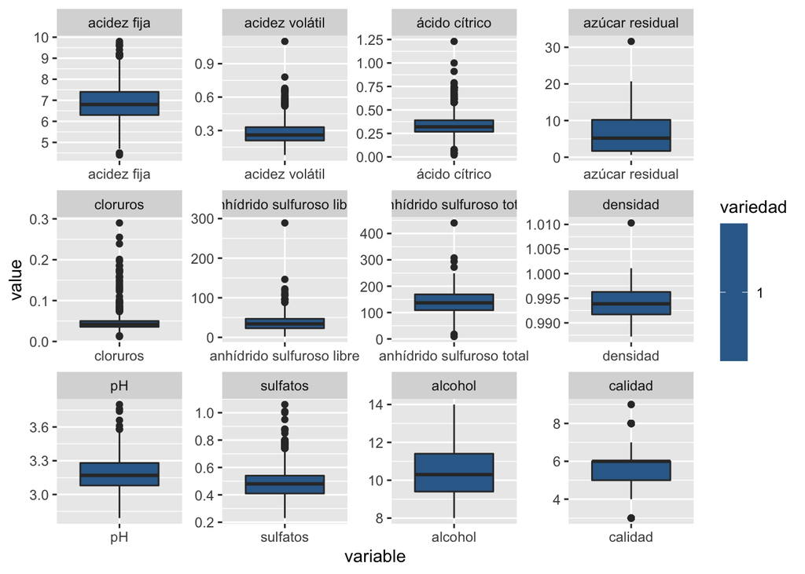

```r
#sample_data <- rbindlist(list(sample_data_var_1, sample_data_var_2))    # Rbind data.tables

sample_data.m <- melt(sample_data, id.var = "variedad")


sample_data_var_1.m <- melt(sample_data_var_1, id.var = "variedad")
#sample_data_var_1.m # pasting some rows of the melted data.frame
ggplot(data = sample_data_var_1.m, aes(x=variable, y=value)) + geom_boxplot(aes(fill=variedad)) + facet_wrap( ~ variable, scales="free")
```

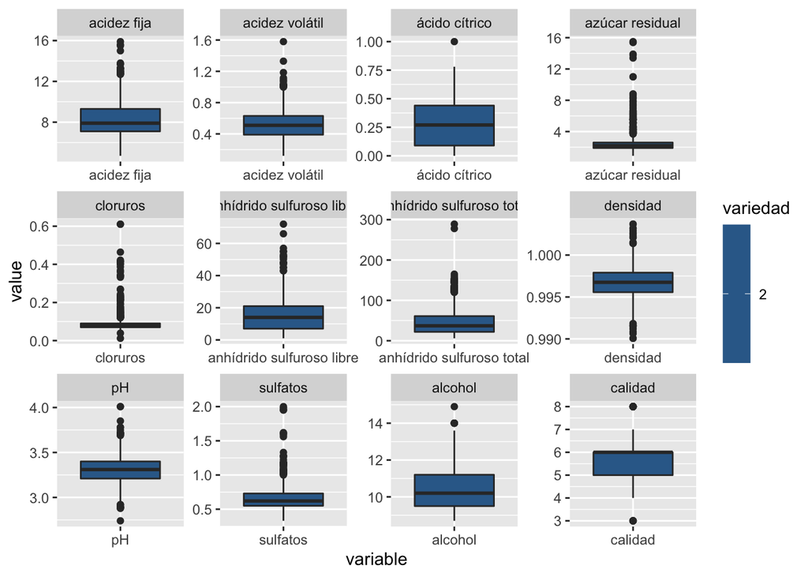

```r
sample_data_var_2.m <- melt(sample_data_var_2, id.var = "variedad")
#sample_data_var_2.m # pasting some rows of the melted data.frame
ggplot(data = sample_data_var_2.m, aes(x=variable, y=value)) + geom_boxplot(aes(fill=variedad)) + facet_wrap( ~ variable, scales="free")
```

Analizo densidad de las variables

[figure not shown]

```r
ggplot(sample_data.m, aes(x = variable, fill = value)) + geom_density(alpha = 1,fill = "lightblue") +
  facet_wrap(~ variable)
```

#### *4.- Presente una tabla de frecuencias y porcentaje para la variable calidad de vino según la variedad (tinto – blanco).*

Tabla de frecuencias *calidad-variedad*

```r
quality = sample_data$calidad
variety = sample_data$variedad

df_qv = data.frame(quality,variety)

freq_vc = table(df_qv)
freq_vc
```

```
##        variety
## quality   1   2
##       3   7   7
##       4  40  33
##       5 284 416
##       6 454 411
##       7 176 118
##       8  37  15
##       9   2   0
```

#### *5.- Realice un gráfico para representar la tabla construida en el punto 4.-*

Gráficos de la tabla de frecuencias *calidad-variedad*

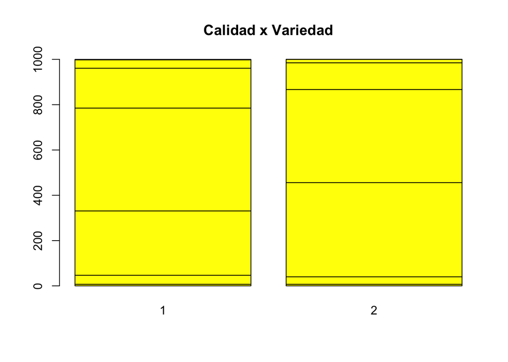

```r
barplot(freq_vc,col='yellow',main="Calidad x Variedad")
```

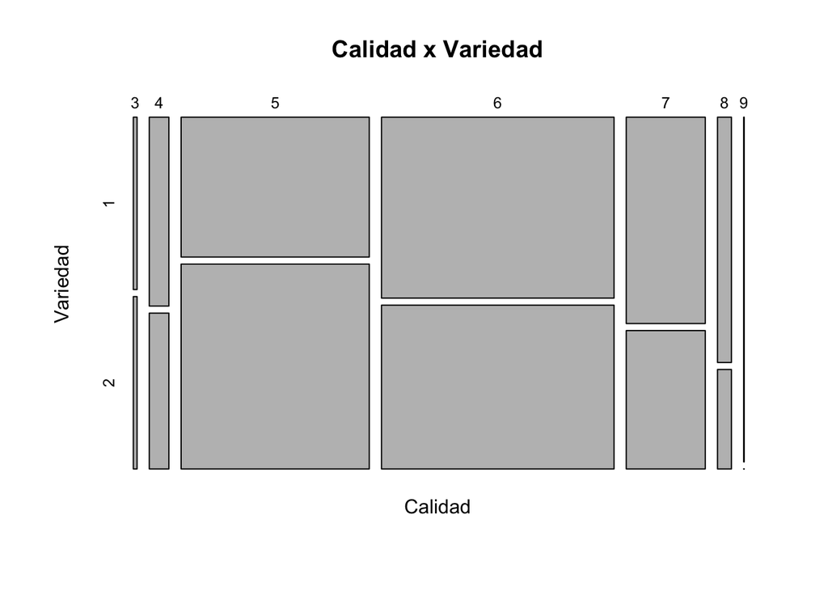

```r
mosaicplot(freq_vc,main="Calidad x Variedad",ylab="Variedad",xlab="Calidad",cex=0.8)
```

#### *6.- Elija dos variables continuas, establezca rangos que representen distintos niveles de cada una y defina nuevas variables categóricas. Aplique un test adecuado para entender si existe asociación entre ambas. Utilice un nivel de significación del 5%.*

##### Análisis variable alcohol

```r
#boxplot(sample_data$densidad)
#boxplot(sample_data$alcohol)

#Supongamos que queremos saber si existe diferencias entre la cantidad de alcohol perteneciente a las diferentes variedades de vinos. Tenemos los siguientes

s_alcohol = sample_data$alcohol
#s_alcohol
#boxplot(s_alcohol)

s_alcohol_cat = cut(s_alcohol, breaks = c(0,10,12,18), labels = c("Low","Medium","High"))

df_av = data.frame(s_alcohol_cat,variety)
#df_av

freq_av = table(df_av)
#freq_av
```

##### Graficamos

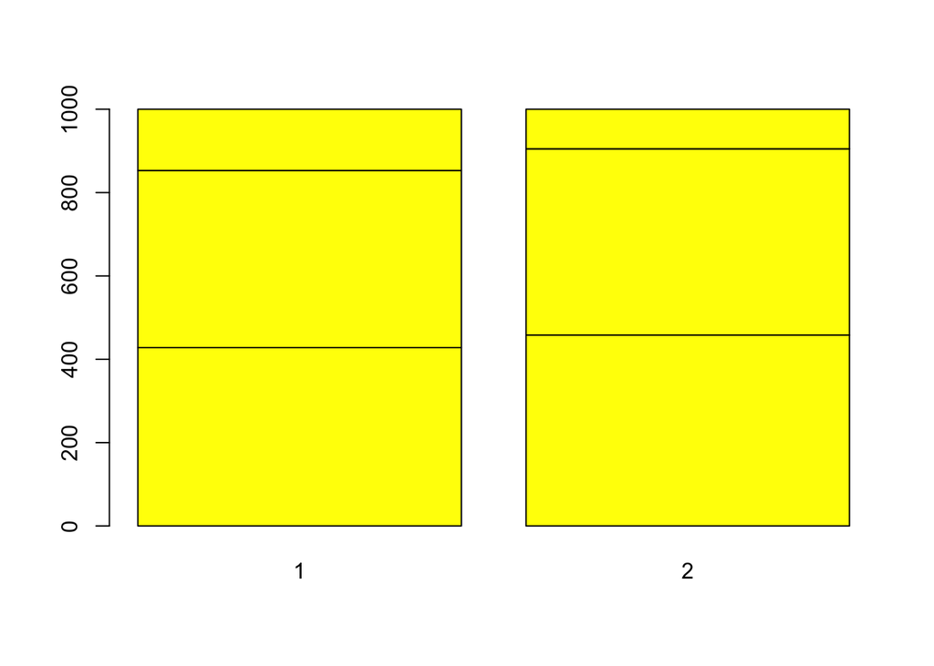

```r
barplot(freq_av,col='yellow')
```

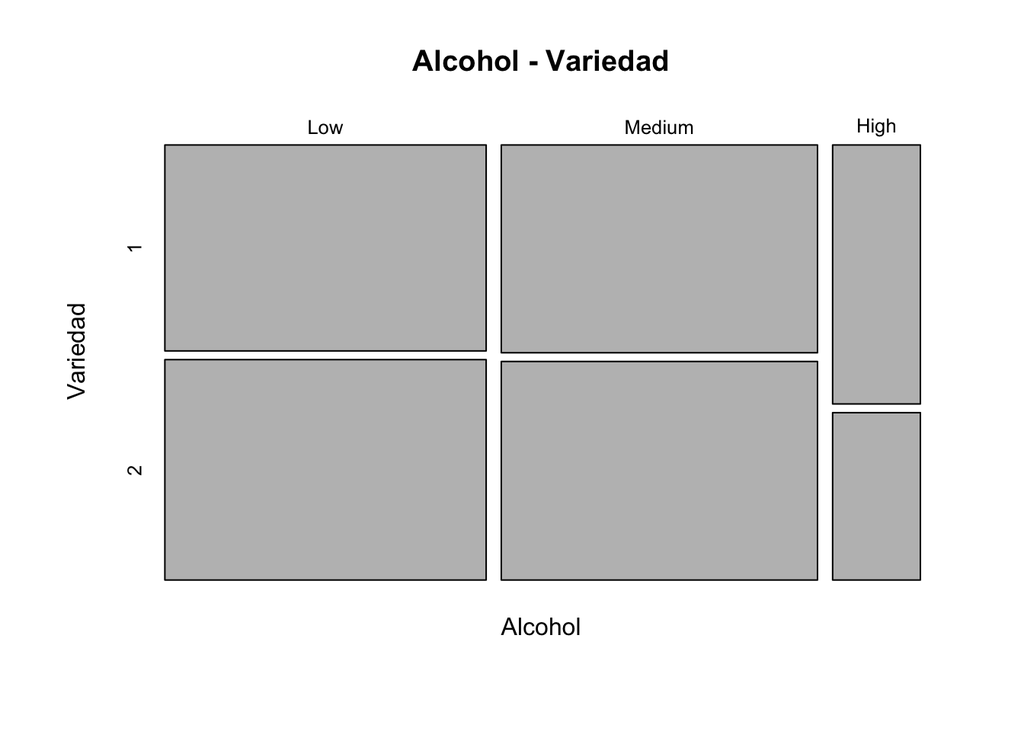

```r
mosaicplot(freq_av,main="Alcohol - Variedad",ylab="Variedad",xlab="Alcohol",cex=0.8)
```

##### Testeamos

Aplicación test Chi-cuadrado

- Tenemos 3 Subniveles para la variable categórica
- Tenemos 2 Poblaciones a analizar

```r
chisq.test(freq_av)
```

```
##
##  Pearson's Chi-squared test
##
## data:  freq_av
## X-squared = 12.744, df = 2, p-value = 0.001708
```

```r
chisq.test(freq_av)$expected
```

```
##              variety
## s_alcohol_cat   1   2
##        Low    443 443
##        Medium 436 436
##        High   121 121
```

```r
chisq.test(freq_av)$residuals
```

```
##              variety
## s_alcohol_cat          1          2
##        Low    -0.7126715  0.7126715
##        Medium -0.5268045  0.5268045
##        High    2.3636364 -2.3636364
```

##### Planteo Hipótesis

H0: La cantidad de alcohol es homogenea en las dos variaciones de vinos, para todas las categorías definidas

H1: La cantidad de alcohol no es homogenea en las dos variaciones de vinos, para todas las categorías definidas

```r
freq_av1<-freq_av[-1,]
freq_av1
```

```
##              variety
## s_alcohol_cat   1   2
##        Medium 425 447
##        High   147  95
```

```r
chisq.test(freq_av1)
```

```
##
##  Pearson's Chi-squared test with Yates' continuity correction
##
## data:  freq_av1
## X-squared = 10.453, df = 1, p-value = 0.001224
```

```r
chisq.test(freq_av1)$expected
```

```
##              variety
## s_alcohol_cat        1        2
##        Medium 447.7415 424.2585
##        High   124.2585 117.7415
```

```r
chisq.test(freq_av1)$residuals
```

```
##              variety
## s_alcohol_cat         1         2
##        Medium -1.074744  1.104087
##        High    2.040119 -2.095819
```

##### Planteo Hipótesis

H0: La cantidad de alcohol es homogenea en las dos variaciones de vinos, para la subpoblación de categorías Medium - High

H1: La cantidad de alcohol no es homogenea en las dos variaciones de vinos, para la subpoblación de categorías Medium - High

```r
freq_av2<-freq_av[-2,]
freq_av2
```

```
##              variety
## s_alcohol_cat   1   2
##          Low  428 458
##          High 147  95
```

```r
chisq.test(freq_av2)
```

```
##
##  Pearson's Chi-squared test with Yates' continuity correction
##
## data:  freq_av2
## X-squared = 11.272, df = 1, p-value = 0.0007867
```

```r
chisq.test(freq_av2)$expected
```

```
##              variety
## s_alcohol_cat        1        2
##          Low  451.6401 434.3599
##          High 123.3599 118.6401
```

```r
chisq.test(freq_av2)$residuals
```

```
##              variety
## s_alcohol_cat         1         2
##          Low  -1.112378  1.134289
##          High  2.128442 -2.170366
```

##### Planteo Hipótesis

H0: La cantidad de alcohol es homogenea en las dos variaciones de vinos, para la subpoblación de categorías Low - High

H1: La cantidad de alcohol no es homogenea en las dos variaciones de vinos, para la subpoblación de categorías Low - High

```r
freq_av3<-freq_av[-3,]
freq_av3
```

```
##              variety
## s_alcohol_cat   1   2
##        Low    428 458
##        Medium 425 447
```

```r
chisq.test(freq_av3)
```

```
##
##  Pearson's Chi-squared test with Yates' continuity correction
##
## data:  freq_av3
## X-squared = 0.017765, df = 1, p-value = 0.894
```

```r
chisq.test(freq_av3)$expected
```

```
##              variety
## s_alcohol_cat        1        2
##        Low    429.8965 456.1035
##        Medium 423.1035 448.8965
```

```r
chisq.test(freq_av3)$residuals
```

```
##              variety
## s_alcohol_cat           1           2
##        Low    -0.09146707  0.08880042
##        Medium  0.09219840 -0.08951043
```

##### Planteo Hipótesis

H1: La cantidad de alcohol no es homogenea en las dos variaciones de vinos, para la subpoblación de categorías Low - Medium

##### Tenemos evidencia para no rechazar la hipótesis nula (alfa) *0,05 < 0.894* (p-valor) con un nivel de significancia de 0,05 para esta subpoblación -> No hay dependencia

##### Análisis variable PH

```r
#boxplot(sample_data$pH)

s_ph = sample_data$pH
#s_ph
#boxplot(s_ph)

s_ph_cat = cut(s_ph, breaks = c(0,3.2,3.35,10), labels = c("Low","Medium","High"))

df_phv = data.frame(s_ph_cat,variety)
#df_phv

freq_phv = table(df_phv)
#freq_phv
```

##### Graficamos

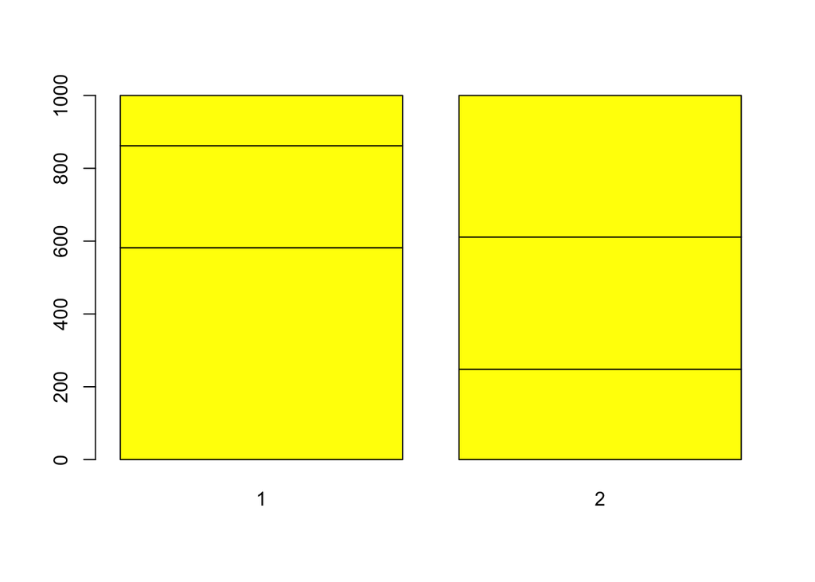

```r
barplot(freq_phv,col='yellow')
```

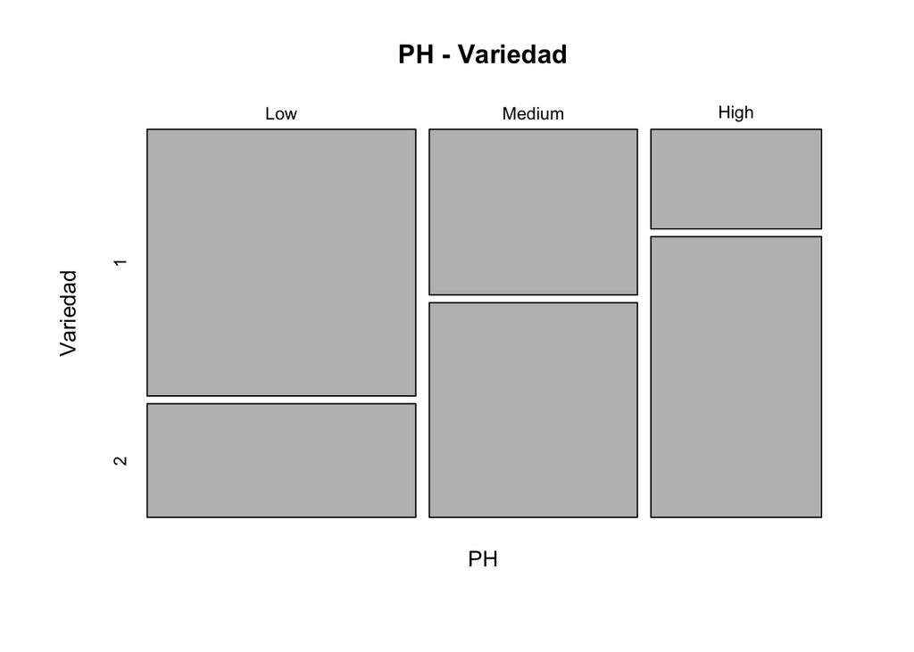

```r
mosaicplot(freq_phv,main="PH - Variedad",ylab="Variedad",xlab="PH",cex=0.8)
```

Aplicación test Chi-cuadrado

- Tenemos 3 Subniveles para la variable categórica
- Tenemos 2 Poblaciones a analizar

```r
chisq.test(freq_phv)
```

```
##
##  Pearson's Chi-squared test
##
## data:  freq_phv
## X-squared = 264.67, df = 2, p-value < 2.2e-16
```

```r
chisq.test(freq_phv)$expected
```

```
##         variety
## s_ph_cat     1     2
##   Low    415.0 415.0
##   Medium 321.5 321.5
##   High   263.5 263.5
```

```r
chisq.test(freq_phv)$residuals
```

```
##         variety
## s_ph_cat         1         2
##   Low     8.197708 -8.197708
##   Medium -2.314502  2.314502
##   High   -7.731316  7.731316
```

```r
freq_phv1<-freq_phv[-1,]
chisq.test(freq_phv1)
```

```
##
##  Pearson's Chi-squared test with Yates' continuity correction
##
## data:  freq_phv1
## X-squared = 37.259, df = 1, p-value = 1.035e-09
```

```r
chisq.test(freq_phv1)$expected
```

```
##         variety
## s_ph_cat        1        2
##   Medium 229.7214 413.2786
##   High   188.2786 338.7214
```

```r
chisq.test(freq_phv1)$residuals
```

```
##         variety
## s_ph_cat         1         2
##   Medium  3.317285 -2.473216
##   High   -3.664232  2.731883
```

```r
freq_phv2<-freq_phv[-2,]
chisq.test(freq_phv2)
```

```
##
##  Pearson's Chi-squared test with Yates' continuity correction
##
## data:  freq_phv2
## X-squared = 248.05, df = 1, p-value < 2.2e-16
```

```r
chisq.test(freq_phv2)$expected
```

```
##         variety
## s_ph_cat        1        2
##     Low  440.3832 389.6168
##     High 279.6168 247.3832
```

```r
chisq.test(freq_phv2)$residuals
```

```
##         variety
## s_ph_cat         1         2
##     Low   6.748378 -7.174571
##     High -8.469020  9.003880
```

##### Planteo Hipótesis

H0: La cantidad de ph es homogenea en las dos variaciones de vinos, para la subpoblación de categorías Low - High

H1: La cantidad de ph no es homogenea en las dos variaciones de vinos, para la subpoblación de categorías Low - High

```r
freq_phv3<-freq_phv[-3,]
chisq.test(freq_phv3)
```

```
##
##  Pearson's Chi-squared test with Yates' continuity correction
##
## data:  freq_phv3
## X-squared = 104.32, df = 1, p-value < 2.2e-16
```

```r
chisq.test(freq_phv3)$expected
```

```
##         variety
## s_ph_cat        1        2
##   Low    485.7162 344.2838
##   Medium 376.2838 266.7162
```

```r
chisq.test(freq_phv3)$residuals
```

```
##         variety
## s_ph_cat         1         2
##   Low     4.368796 -5.189133
##   Medium -4.963584  5.895605
```

#### *7.- Seleccione otra variable continua y estime la diferencia de medias según la variedad del vino con un nivel de confianza del 95%. Interprete el resultado obtenido.*

Buscamos estimar la diferencia de las medias en la densidad de ambas variedades (dos poblaciones).

Tomamos normalidad por teorema central del límite

#### Graficamos

Check visual de normalidad

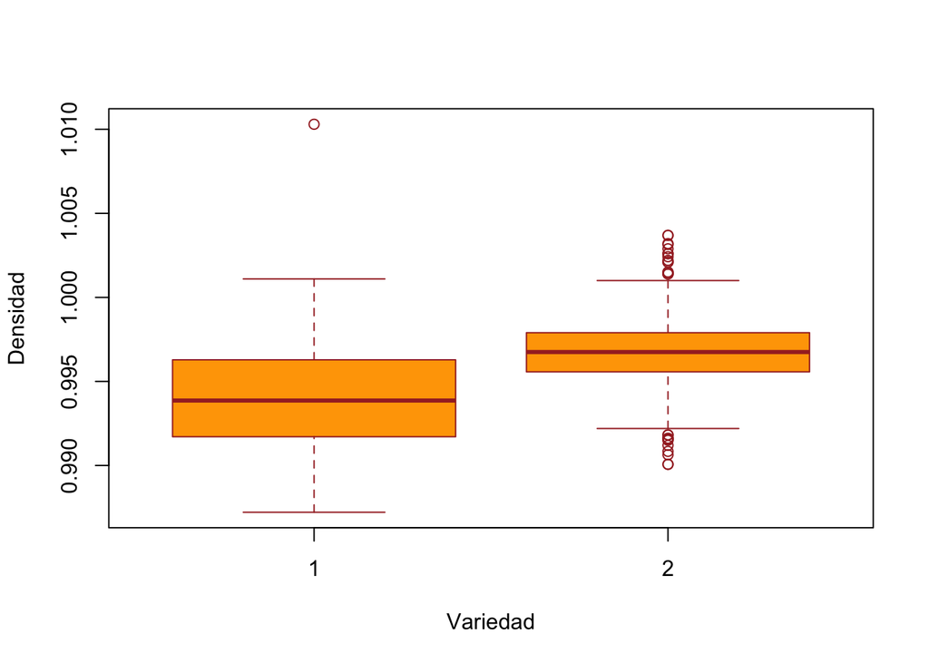

```r
boxplot(densidad~variedad, data=sample_data,xlab="Variedad",ylab="Densidad",col="orange",border="brown")
```

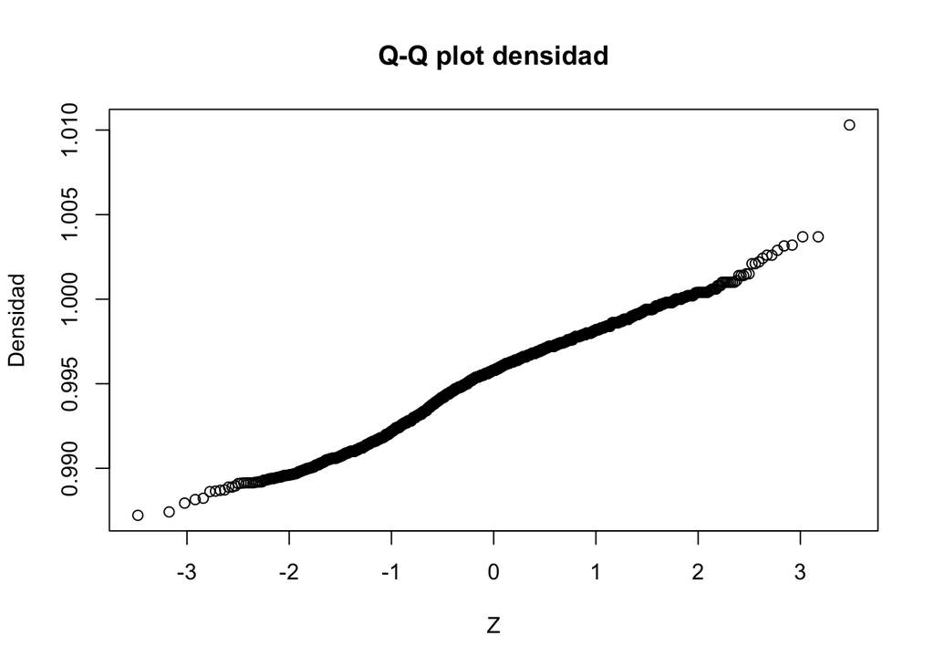

```r
qqnorm(sample_data$densidad, main = "Q-Q plot densidad", ylab = "Densidad", xlab = "Z" )
```

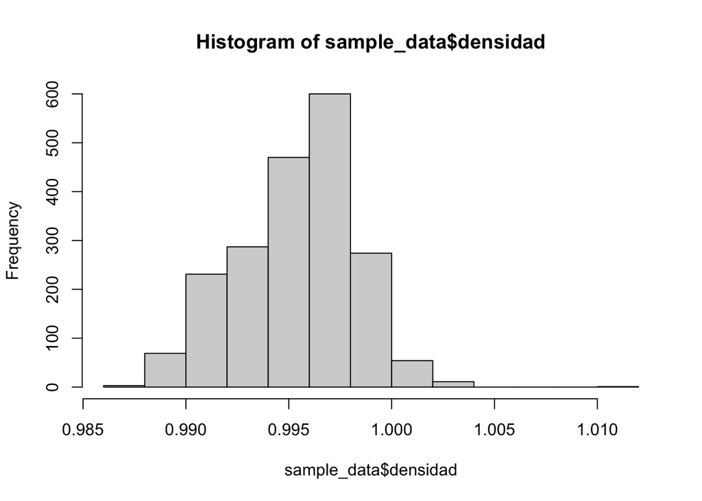

```r
hist(sample_data$densidad)
```

#### Planteo hipotesis

Ho: Var1 = Var2

H1: Var1 != Var2

No tenemos la varianza poblacional, por lo que hacemos una prueba de hipótesis para saber si las varianzas son iguales o no (prueba bilateral)

```r
var.test(densidad~variedad, data=sample_data, alternative = "two.sided") # es una prueba bilateral
```

```
##
##  F test to compare two variances
##
## data:  densidad by variedad
## F = 2.3634, num df = 999, denom df = 999, p-value < 2.2e-16
## alternative hypothesis: true ratio of variances is not equal to 1
## 95 percent confidence interval:
##  2.087614 2.675686
## sample estimates:
## ratio of variances
##            2.36343
```

Hacemos la prueba con varianzas no iguales

##### Con una prueba del estadístico T

```r
t.test(densidad~variedad , data=sample_data, alternative = "two.sided", var.equal = F, conf.level = 0.95)
```

```
##
##  Welch Two Sample t-test
##
## data:  densidad by variedad
## t = -23.872, df = 1716, p-value < 2.2e-16
## alternative hypothesis: true difference in means between group 1 and group 2 is not equal to 0
## 95 percent confidence interval:
##  -0.002899968 -0.002459622
## sample estimates:
## mean in group 1 mean in group 2
##       0.9940928       0.9967726
```

##### *Representamos el intervalo de confianza IC (-0.002899968, -0.002459622)*

##### *Valores estadísticos t = -23.872, df = 1716, p-value < 2.2e-16*

##### *=> Mx es menos que My diferencias de medias contra menor*

##### *H0: Mx = My*

##### *H1: Mx < My*

##### *Vemos que el alfa* *0,05 > 2.2e-16* *p-valor propuesta por lo que rechazamos la hipótesis nula*

##### Con una prueba del estadístico Z

```r
z.test(x=sample_data$densidad,y=sample_data$variedad,alternative="two.sided",mu=0,sigma.x=sd(sample_data$densidad),sigma.y=sd(sample_data$variedad),conf.level=0.95)
```

```
##
##  Two-sample z-Test
##
## data:  sample_data$densidad and sample_data$variedad
## z = -45.118, p-value < 2.2e-16
## alternative hypothesis: true difference in means is not equal to 0
## 95 percent confidence interval:
##  -0.5264862 -0.4826484
## sample estimates:
## mean of x mean of y
## 0.9954327 1.5000000
```

```r
# IC(-0.5264862, -0.4826484)
# prueba sobre menos
```

##### Valores estadísticos z = -45.118, p-value < 2.2e-16

##### => Mx es menos que My diferencias de medias contra menor

##### *H0: Mx = My*

##### *H1: Mx < My*

##### *Vemos que el alfa* *0,05 > 2.2e-16* *p-valor propuesta por lo que rechazamos la hipótesis nula*

#### *8.- Según el resultado obtenido en el punto 7.- realice un test de hipótesis apropiado para determinar la diferencia de medias de la variable en estudio. Trabaje con una significación del 5%. Presente el planteo de hipótesis adecuado, la resolución y la decisión a tomar.*

Buscamos estimar la diferencia de las medias en la densidad de ambas variedades (dos poblaciones).

Tomamos normalidad por teorema central del límite

No tenemos la varianza poblacional, por lo que hacemos una prueba de hipótesis para saber si las varianzas son iguales o no (prueba bilateral)

##### Planteo hipotesis sobre las varianzas

###### *Ho: Var1 = Var2*

###### *H1: Var1 != Var2*

###### *=> no son iguales las variazas*

##### Hacemos la prueba con varianzas no iguales

##### Obtenemos los estadisticos e IC

###### *=> Mx es menos que My diferencias de medias contra menor*

##### Planteo hipotesis sobre las medias

##### *H0: Mx = My*

##### *H1: Mx < My*

##### *Vemos que el alfa* *0,05 > 2.2e-16* *p-valor propuesta por lo que rechazamos la hipótesis nula*

#### *9.- ¿Se puede afirmar que hay diferencias significativas en la calidad del vino tinto respecto al vino blanco? Elija un test de hipótesis adecuado. Trabaje con una significación del 5%.*

```r
#glimpse(sample_data)
sample_quality_var1 = sample_data %>% filter(sample_data$variedad == 1)
sample_quality_var2 = sample_data %>% filter(sample_data$variedad == 2)

#sample_quality_var1$calidad
#sample_quality_var2$calidad
#tcl normal, deberia usar Z, Tiende aproximarse a la normalidad
shapiro.test(sample_data_var_1$calidad)
```

```
##
##  Shapiro-Wilk normality test
##
## data:  sample_data_var_1$calidad
## W = 0.89525, p-value < 2.2e-16
```

```r
#p muy bajo entonces rechazo hipotesis de normalidad => Puede ser un valor atipico
shapiro.test(sample_data_var_2$calidad)
```

```
##
##  Shapiro-Wilk normality test
##
## data:  sample_data_var_2$calidad
## W = 0.85967, p-value < 2.2e-16
```

```r
#p muy bajo entonces rechazo hipotesis de normalidad
summary(sample_data_var_1$calidad)
```

```
##    Min. 1st Qu.  Median    Mean 3rd Qu.    Max.
##   3.000   5.000   6.000   5.871   6.000   9.000
```

```r
summary(sample_data_var_2$calidad)
```

```
##    Min. 1st Qu.  Median    Mean 3rd Qu.    Max.
##   3.000   5.000   6.000   5.645   6.000   8.000
```

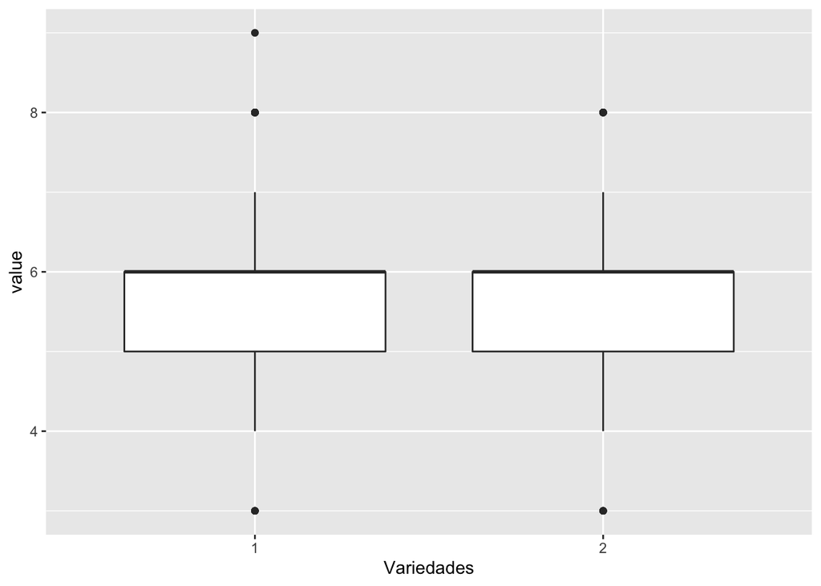

```r
#Graficamos
myList <-list(sample_data_var_1$calidad, sample_data_var_2$calidad)
df <- melt(myList)
#df

qplot(factor(L1), value, data = df, geom = "boxplot", xlab="Variedades")
```

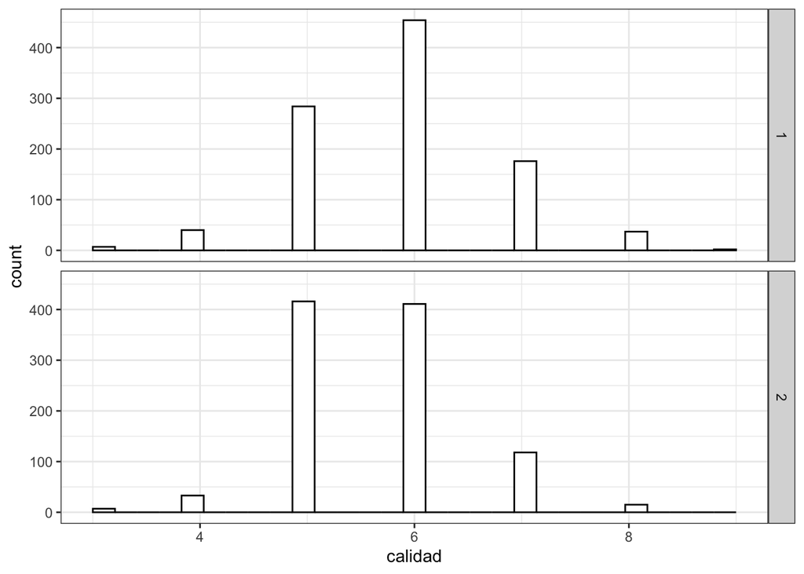

```r
ggplot(sample_data, aes(x = calidad)) +
  geom_histogram(fill = "white", colour = "black") +
  facet_grid(variedad ~ .) + theme_bw()
```

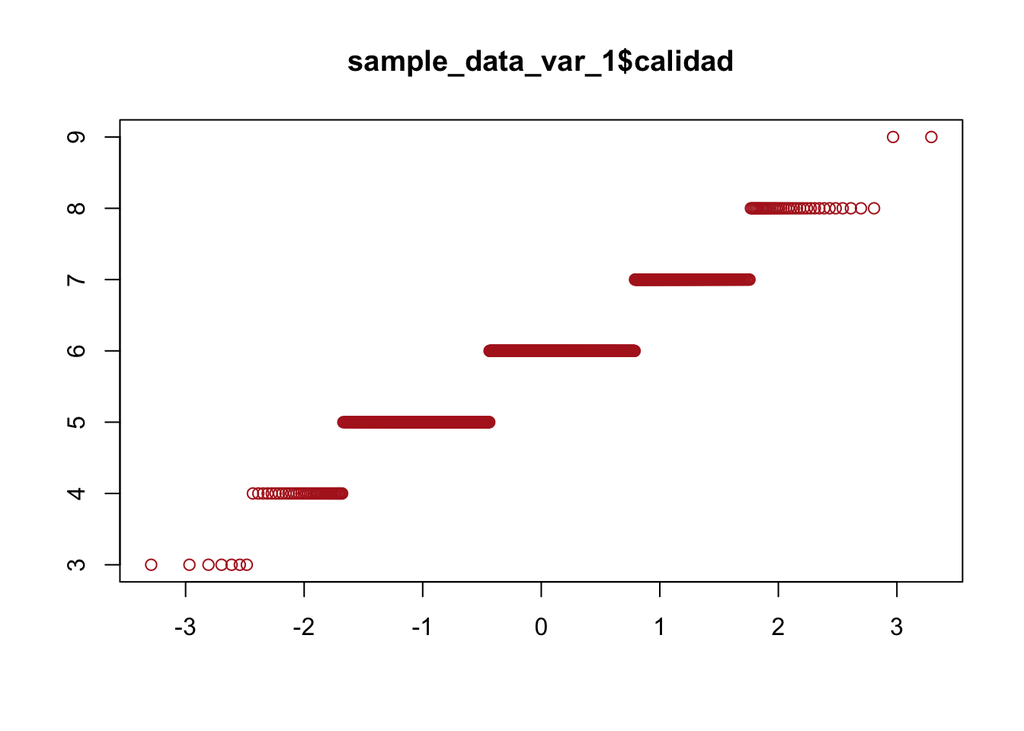

```r
qqnorm(sample_data_var_1$calidad, xlab = "", ylab = "",
       main = "sample_data_var_1$calidad", col = "firebrick")
```

[figure not shown]

```r
qqnorm(sample_data_var_2$calidad, xlab = "", ylab = "",
       main = "sample_data_var_1$calidad", col = "springgreen4")
```

##### *Usando wilcox, obtengo un p-valor muy chico, pero dado a problemas con empates, prosigo a suponer normalidad por TCL y utilizar t.test para testear la diferencia de medias* (Lo dejo como evidencia de pruebas)

```r
wilcox.test(sample_data_var_1$calidad, sample_data_var_2$calidad,alternative = "two.sided")
```

```
##
##  Wilcoxon rank sum test with continuity correction
##
## data:  sample_data_var_1$calidad and sample_data_var_2$calidad
## W = 573416, p-value = 1.166e-09
## alternative hypothesis: true location shift is not equal to 0
```

```r
# p-value = 1.166e-09 por lo que rechazamos la hipotesis nula, hay diferencias en la mediana poblacional
```

##### *Pruebo con t.test. Al ser una cantidad significativa de valores, tambien habria que descartar este test* (Lo dejo como evidencia de pruebas)

```r
#Pruebo con t.test
t.test(x=sample_data_var_1$calidad, y= sample_data_var_2$calidad, alternative = "two.sided", mu=0,
       var.equal = F, conf.level = 0.95)
```

```
##
##  Welch Two Sample t-test
##
## data:  sample_data_var_1$calidad and sample_data_var_2$calidad
## t = 5.8415, df = 1972.7, p-value = 6.038e-09
## alternative hypothesis: true difference in means is not equal to 0
## 95 percent confidence interval:
##  0.1501246 0.3018754
## sample estimates:
## mean of x mean of y
##     5.871     5.645
```

```r
#IC (0.1501246 0.3018754)
#Ho Mx-My = 0
#Ha Mx-My > 0

#Siendo p-valor = 6.038e-09 < 0,05 => rechazamos la hipotesis nula, hay diferencias en la mediana poblacional
```

#### Dado los valores arrojadon por la prueba de t.test

##### IC (0.1501246 0.3018754) => Realizo hipotesis comparando con mayor

##### *Ho: Mx-My = 0*

##### *Ha: Mx-My > 0*

##### *Siendo p-valor = 6.038e-09 < 0,05 => rechazamos la hipotesis nula, hay diferencias en la mediana poblacional*

##### *Realizo la prueba con z.test => Conjunto de valor grandes, normalidad por TCL*

```r
z.test(x=sample_data_var_1$calidad,
       y= sample_data_var_2$calidad,
       alternative="two.sided",
       mu=0,
       sigma.x=sd(sample_data_var_1$calidad),
       sigma.y=sd(sample_data_var_2$calidad),
       conf.level=0.95)
```

```
##
##  Two-sample z-Test
##
## data:  sample_data_var_1$calidad and sample_data_var_2$calidad
## z = 5.8415, p-value = 5.174e-09
## alternative hypothesis: true difference in means is not equal to 0
## 95 percent confidence interval:
##  0.1501712 0.3018288
## sample estimates:
## mean of x mean of y
##     5.871     5.645
```

##### IC (0.1501712 0.3018288) => Realizo hipotesis comparando con mayor

##### *Ho: Mx-My = 0*

##### *Ha: Mx-My > 0*

##### *Siendo p-valor = 5.174e-09 < 0,05 => rechazamos la hipotesis nula, hay diferencias en la mediana poblacional*

#### *10.- Decida si existen diferencias significativas en las proporciones de alcohol entre los vinos de calidad baja, media y alta. Justifique.*

#### Planteo hipótesis

H0: No existen diferencias significativas en las proporciones de alcohol ente los vinos de calidad baja, media y alta H1: Existen diferencias significativas en las proporciones de alcohol ente los vinos de calidad baja, media y alta

#### Graficamos y preparamos los datos

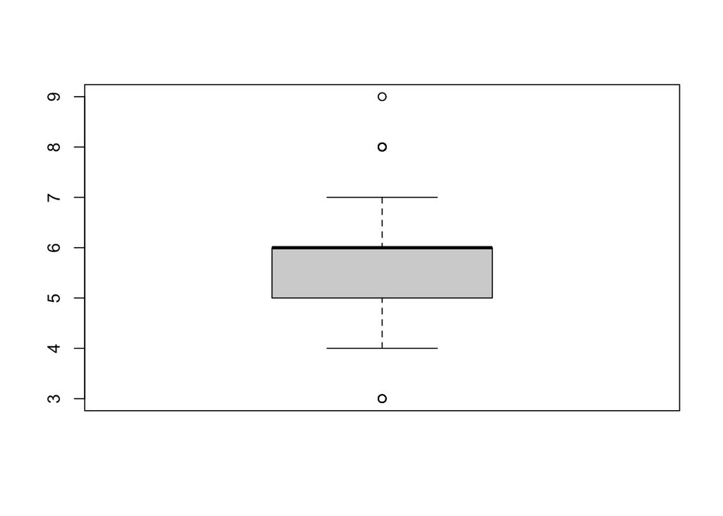

```r
s_calidad  = sample_data$calidad
#s_calidad
boxplot(s_calidad)
```

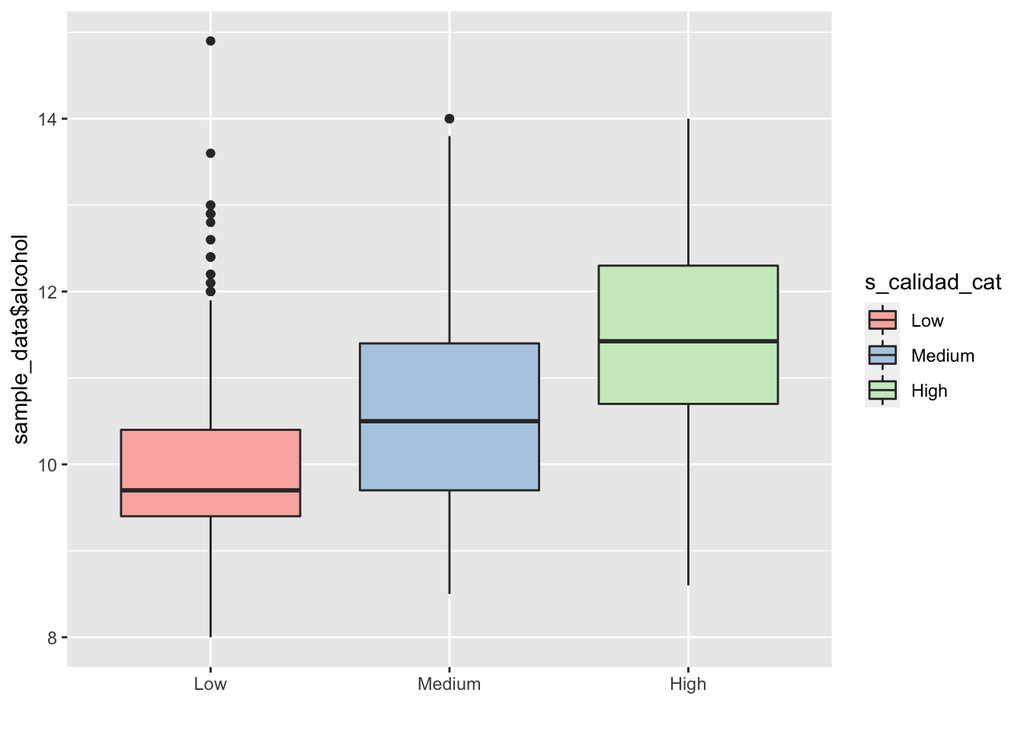

```r
s_calidad_cat = cut(s_calidad, breaks = c(0,5,6,18), labels = c("Low","Medium","High"))
#s_calidad_cat
df_cal_alcohol = data.frame(sample_data$alcohol,s_calidad_cat)
#df_cal_alcohol


ggplot(df_cal_alcohol,aes(x=s_calidad_cat,y=sample_data$alcohol,fill=s_calidad_cat)) + geom_boxplot() + xlab("") + scale_fill_brewer(palette="Pastel1")
```

```r
#df_cal_alcohol

# Produce boxplots
grupoA=df_cal_alcohol[df_cal_alcohol$s_calidad_cat=="Low",1]
grupoB=df_cal_alcohol[df_cal_alcohol$s_calidad_cat=="Medium",1]
grupoC=df_cal_alcohol[df_cal_alcohol$s_calidad_cat=="High",1]
```

#### Probamos normaliadd

```r
shapiro.test(grupoA)
```

```
##
##  Shapiro-Wilk normality test
##
## data:  grupoA
## W = 0.90323, p-value < 2.2e-16
```

```r
shapiro.test(grupoB)
```

```
##
##  Shapiro-Wilk normality test
##
## data:  grupoB
## W = 0.96755, p-value = 5.957e-13
```

```r
shapiro.test(grupoC)
```

```
##
##  Shapiro-Wilk normality test
##
## data:  grupoC
## W = 0.98323, p-value = 0.0004466
```

```r
# Vemos que las pruebas de shapiro arrojan un valor muy bajo por lo que no tenemos normalidad, entonces procedemos a usar kruskal
```

#### Realizamos test de kruskal para analizar si existen diferencias significativas

```r
kruskal.test(sample_data$alcohol, s_calidad_cat)# Realiza el test de Kruskal
```

```
##
##  Kruskal-Wallis rank sum test
##
## data:  sample_data$alcohol and s_calidad_cat
## Kruskal-Wallis chi-squared = 407.08, df = 2, p-value < 2.2e-16
```

```r
#Vemos el p-valor muy chico por lo que determinamos rechazar la hipotesis, sabemos que alguno de los grupos difiere

kruskalmc(sample_data$alcohol~s_calidad_cat )# Realiza un test de comparación múltiple entre tratamientos luego del test de Kruskal Wallis
```

```
## Multiple comparison test after Kruskal-Wallis
## p.value: 0.05
## Comparisons
##              obs.dif critical.dif difference
## Low-Medium  353.7915     68.10484       TRUE
## Low-High    725.9771     88.99986       TRUE
## Medium-High 372.1856     87.76091       TRUE
```

#### Obtenemos un p-valor bien bajo por lo que rechazamos la hipótesis nula, definimos que existen diferencias significativas entre los vinos de calidad baja, media y alta dada una significancia de 0,05

11.- Presente un informe final con un mínimo de 500 y un máximo de 800 palabras del análisis de la base de datos, describiendo la base de datos, indicando la presencia de valores atípicos y las conclusiones a las que se abordó luego del análisis.

#### Conclusiones

*Se observa en todas las variables una cantidad de outliers muy importantes, los cuales perjudican a los calculos que estamos realizando a lo largo del trabajo practico, seria adecuado poder vovler a realizar las mismas pruebas y analisis eliminiandolos o revisando si es necesaria alguna imputacion. Estos datos atipicos generan una ponderacion mayor que aquellos cercanos a la media lo que puede conducir a interpretaciones engañosas de las diferentes pruebas realizadas sobre las variables.*

*Por ejemplo podemos observar para el conjunto de datos asociados a la variedad 1, los atributos acidez volatil, ácido cítrico, cloruro, anhídrico sulfiroso libre, presentan debido a los outliers una dispersion muy grandes de los datos, necesitan una tratamiento importante*

*En el conjunto de datos asociados a la variedad 2, los atributos azucar residual, cloruros, sultafo, presentan debido a los outliers una dispersión muy grandes de los datos, necesitan una tratamiento importante*

*Para el analisis de homogeneidad del ph, nos arroja que no existe homogeneidad entre las distintas variedades de vinos para las subpoblaciones determinadas en el analisis.*

*En cuanto a la calidad de los vinos, a pesar que graficamente parecen muy similares las medias asociadas a cada una de las distintas variedades, al realizar los tests correspondientes, nos encontramos que con una significancia del 0,05, el test rechaza la hipotesis nula de igualdad, siendo el vino blanco de mayor calidad que el vino tinto.*